# IE 582 HW1

## *Ozlem Akekmekci*

### *November 1,2021*

In this homework, there are 2 different tasks. Task 1 is about the curse of dimensionality. In Task 1, firstly we generate some points for different dimensions and calculate the approximation of the volume of unit hypersphere within the unit hypercube. This enables us to find pi approximation. Then in the final part, we make calculations to find nearest neighborhood for the test points we have generated.

Task 2 is mostly focuses on data manipulation techniques used for image processing. By using our own 512*512 px photos, we make some manipulation on each RGB channel and add noise on original images. At the end of each manipulation, we display the manipulated image (with all channels) and images of each channel separately.

## **TASK 1 - Curse of dimensionality and effect of sample size**

To begin this task, I have firstly simulated 1000 random D-dimensional points ~ U(-1,1) for D from 1 to 15.

```r
#Simulate 1000 random points D-dimensional points

n = 1000    #Since we will use larger sample sizes afterwards, I defined such "n".
d_list = list()
for (i in 1:15)
  d_list[[i]] = matrix(runif(n*i,-1,1),i,n)
```

**A)** In this part, first I have found the Euclidean distance between each D-dimensional point.

```r
d_dist = list()
for (i in 1:15)
{
  d_dist[[i]] = rep(0,n)
  for(j in 1:n)
    d_dist[[i]][j] = sqrt(sum((d_list[[i]][,j]-0)^2))
}
```

Then, I found the number of points that have distance, between origin, less than 1.

```r
less_than_1 = rep(0,15)

for (i in 1:15)
  less_than_1[i] = sum(d_dist[[i]]<=1)

print(less_than_1)
```

```
##  [1] 1000  789  513  322  161   74   26   15    4    3    1    1    0    0    0
```

**B)** For each dimension, by using the fraction of these points, I found the approximation for pi, $\pi$.

The fraction is equal to the (number of points within distance 1)/(total number of points, which is 1000 in this case)

Then,

```r
d2_pi <- (less_than_1[2]/n)*4
d3_pi <- (less_than_1[3]/n)*6

print(d2_pi)
```

```
## [1] 3.156
```

```r
print(d3_pi)
```

```
## [1] 3.078
```

**C)** In this part, questions asks us to perform the same calculations with different sample sizes. So, I have defined a function “pi_aproximator” that takes the sample size as an input and perform above calculations to find pi approximation for each sample size.

```r
pi_approximator = function(n)
{
  d_list = list()
  for (i in 1:15)
    d_list[[i]] = matrix(runif(n*i,-1,1),i,n)



  d_dist = list()
  for (i in 1:15)
  {
    d_dist[[i]] = rep(0,n)
    for(j in 1:n)
      d_dist[[i]][j] = sqrt(sum((d_list[[i]][,j]-0)^2))
  }

  less_than_1 = rep(0,15)

  for (i in 1:15)
    less_than_1[i] = sum(d_dist[[i]]<=1)



  d2_pi = (less_than_1[2]/n)*4
  d3_pi = (less_than_1[3]/n)*6
  print(c("For sample size: ", n))
  print(c("Pi Approximation in 2D: ",d2_pi))
  print(c("Pi Approximation in 3D: ",d3_pi))
  c(d2_pi,d3_pi)
}

results = matrix(rep(0,6*3),6)
results[,1] = c(1000,5000,10000,25000,50000,100000)

for(i in 1:6)
  results[i,2:3] = pi_approximator(results[i,1])
```

```
## [1] "For sample size: " "1000"
## [1] "Pi Approximation in 2D: " "3.176"
## [1] "Pi Approximation in 3D: " "3.144"
## [1] "For sample size: " "5000"
## [1] "Pi Approximation in 2D: " "3.1512"
## [1] "Pi Approximation in 3D: " "3.1632"
## [1] "For sample size: " "10000"
## [1] "Pi Approximation in 2D: " "3.1472"
## [1] "Pi Approximation in 3D: " "3.1482"
## [1] "For sample size: " "25000"
## [1] "Pi Approximation in 2D: " "3.128"
## [1] "Pi Approximation in 3D: " "3.15048"
## [1] "For sample size: " "50000"
## [1] "Pi Approximation in 2D: " "3.13016"
## [1] "Pi Approximation in 3D: " "3.13596"
## [1] "For sample size: " "1e+05"
## [1] "Pi Approximation in 2D: " "3.141"
## [1] "Pi Approximation in 3D: " "3.14364"
```

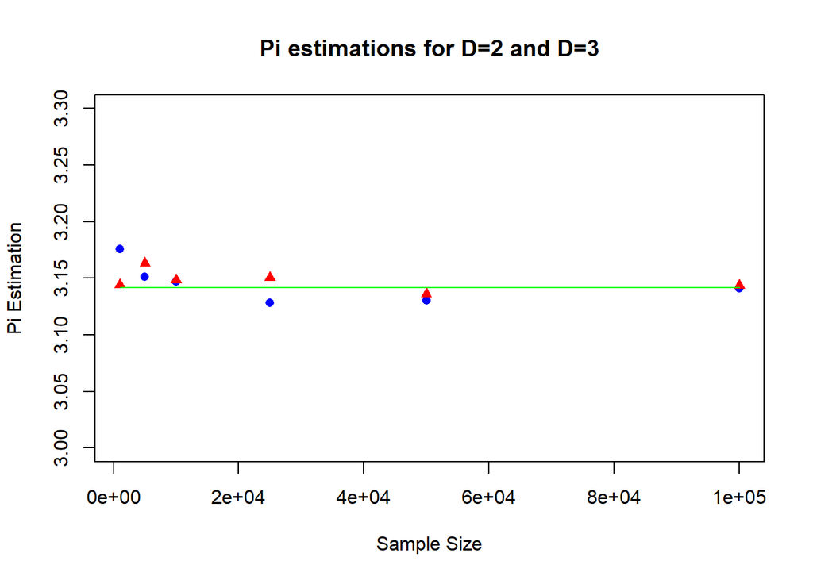

```r
plot(results[,1],results[,2], col = "blue", pch = 16, ylim = c(3,3.3), main= 'Pi estimations for D=2 and D=3', xlab= "Sample Size", ylab = "Pi Estimation")

points(results[,1],results[,3], col = "red", pch = 17)
lines(results[,1],rep(pi,6), col = "green", )
```

As sample size increases, $\pi$ approximator finds values closer to 3.14. So, we can say that as sample size increases, accuracy increases. In our case, this is also reasonable in intuitive way. Since we are using points within the unit hypercube and hypersphere to estimate pi value, as the number of sample points within them increases, the precision of our estimates increases naturally.

**D)** In this part, from 1 to 15 dimensions, I generated additional 100 random D-dimensional test instances and find the nearest neigbor for each of them. Then, I displayed the average distance for each dimension with a plot.

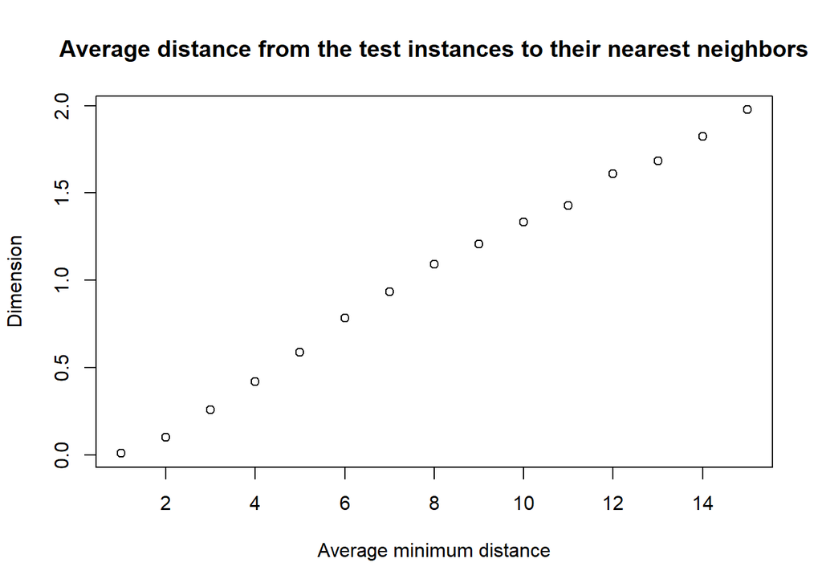

```r
d_list = list()
for (i in 1:15)
  d_list[[i]] = matrix(runif(1000*i,-1,1),i,1000) #above simulation is repeated

test_instances = list()
for (i in 1:15)
  test_instances[[i]] = matrix(runif(100*i,-1,1),i,100) #generated additional 100 test instances for each D.

distance_matrices = list()

for (i in 1:15)
  distance_matrices[[i]] = matrix(rep(0,100^2),100)


dist_fnc = function(x,y) # to find euclidean distance between given two points
{
  sqrt(sum((x-y)^2))
}

for(i in 1:15)
{  for(j in 1:100)
    {
    for(k in 1:100)
      distance_matrices[[i]][j,k] = dist_fnc(test_instances[[i]][,j],test_instances[[i]][,k])

    distance_matrices[[i]][j,j] = 1000000 #self-distance set to be very large to eliminate it.
    }
}

nearest_neighbor_dist = list()

for(i in 1:15)
{
  nearest_neighbor_dist[[i]] = rep(0,100)
  for(j in 1:100)
    nearest_neighbor_dist[[i]][j] = min(distance_matrices[[i]][j,])
}

avg_dists = rep(0,15)

for(i in 1:15)
  avg_dists[i] = mean(nearest_neighbor_dist[[i]])

plot(1:15,avg_dists, main = 'Average distance from the test instances to their nearest neighbors' , xlab= "Average minimum distance", ylab= "Dimension")
```

Above plot shows that, as dimension increases the average of the nearest neighbor increases. This is also reasonable intuitively. Because, in our case, even though we increase the dimensions, the number of points we use for each dimension stays same. Then, it is reasonable to find smaller distances for smaller dimensions.

## **TASK 2 - Practicing data manipulation skills on images**

**A)** To begin this task, I installed package “jpeg” that reads my 512*512 px photo into variable.

```r
library(jpeg)
photo <- readJPEG("IE582Photo.jpg", native = FALSE)
```

Then, I found the dimensions of the photo.

```r
dim(photo)
```

```
## [1] 512 512   3
```

Above dimensions gives us the information we have three 512*512 matrices in this photo since the size of the photo is 512*512 and it has 3 different channels for red, green and blue.

After finding dimensions, I displayed the image by using “rasterImage” command.

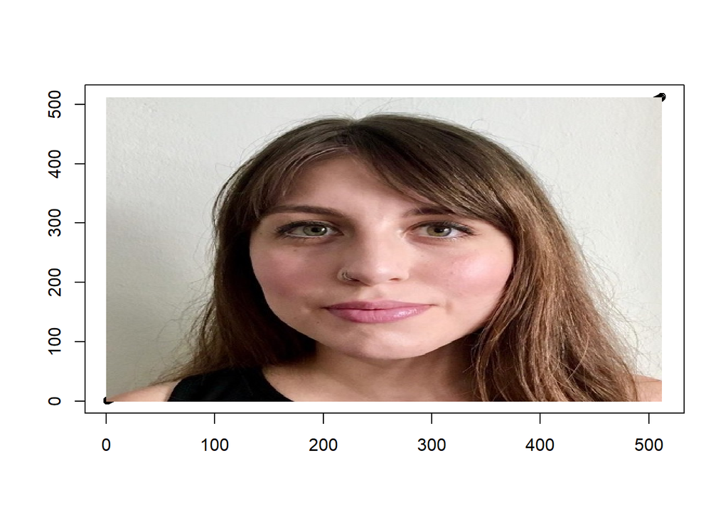

```r
plot(1:512, 1:512, ann=FALSE)
rasterImage(photo,
            0, 0, 512, 512,
            interpolate=FALSE)
```

**B)** To display each channel as seperate image, I equalized all other channels to zero and displayed each of them by using RasterImage.

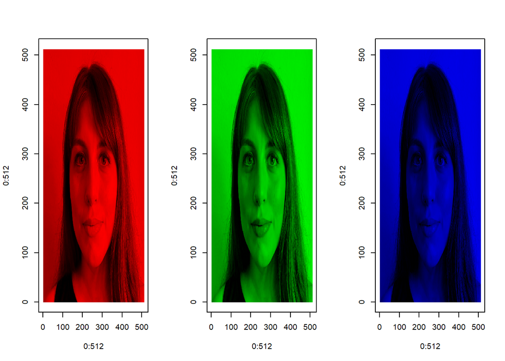

```r
par(mfrow=c(1,3))
redChannel <- photo
redChannel[,,2:3]=0
plot(0:512, 0:512, type="n")
rasterImage(redChannel,
            0, 0, 512, 512,
            interpolate=FALSE)

greenChannel <- photo
greenChannel[,,c(1,3)]=0
plot(0:512, 0:512, type="n")
rasterImage(greenChannel,
            0, 0, 512, 512,
            interpolate=FALSE)

blueChannel <- photo
blueChannel[,,1:2]=0
plot(0:512, 0:512, type="n")
rasterImage(blueChannel,
            0, 0, 512, 512,
            interpolate=FALSE)
```

**C)** For each channel(so, for each matrix) we have 512 columns and 512 rows. We need to take the average of each column for each channel.

Then, I plotted average of the columns and plot them a a line plot for each channel.

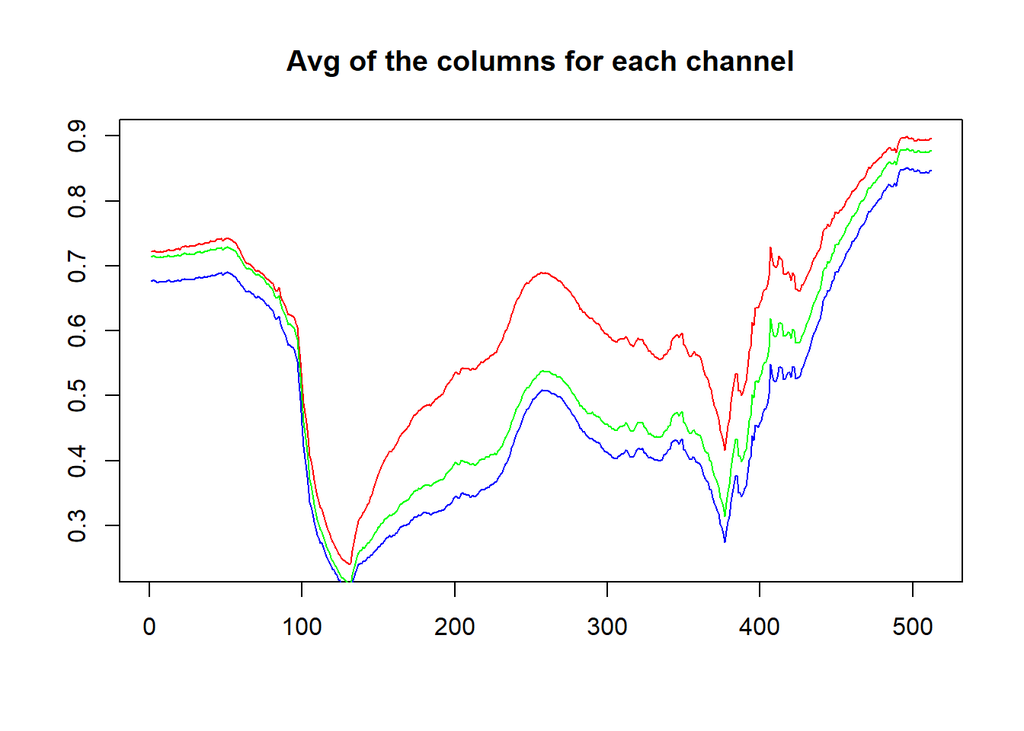

```r
plot(colMeans(redChannel)[,1], type="l", main= 'Avg of the columns for each channel', col="red", xlab="", ylab="")
lines(colMeans(greenChannel)[,2], col="green")
lines(colMeans(blueChannel)[,3], col="blue")
```

**D)** In this part, I will subtract one half of the image from other half for each channel. To do this, I will work with the matrices that have dimensions 512*256*3 for each channel. We have still 3 channels for each matrices but all the elements in 2 other colour channels are equal to zero for each matrix.

```r
redhalf1 <- redChannel[1:512, 1:256,]
redhalf2 <- redChannel[1:512, 257:512,]
redSubtract <- redhalf1 - redhalf2
redSubtract[redSubtract<0] <- 0 #negative pixel values are converted to zero.

greenhalf1 <- greenChannel[1:512, 1:256,]
greenhalf2 <- greenChannel[1:512, 257:512,]
greenSubtract <- greenhalf1 - greenhalf2
greenSubtract[greenSubtract<0] <- 0


bluehalf1 <- blueChannel[1:512, 1:256,]
bluehalf2 <- blueChannel[1:512, 257:512,]
blueSubtract <- bluehalf1 - bluehalf2
blueSubtract[blueSubtract<0] <- 0
```

Since, all these matrices have dimensions 512*256*3 as explained above, I can directly sum them to have the new image combing all three subtracted channels.

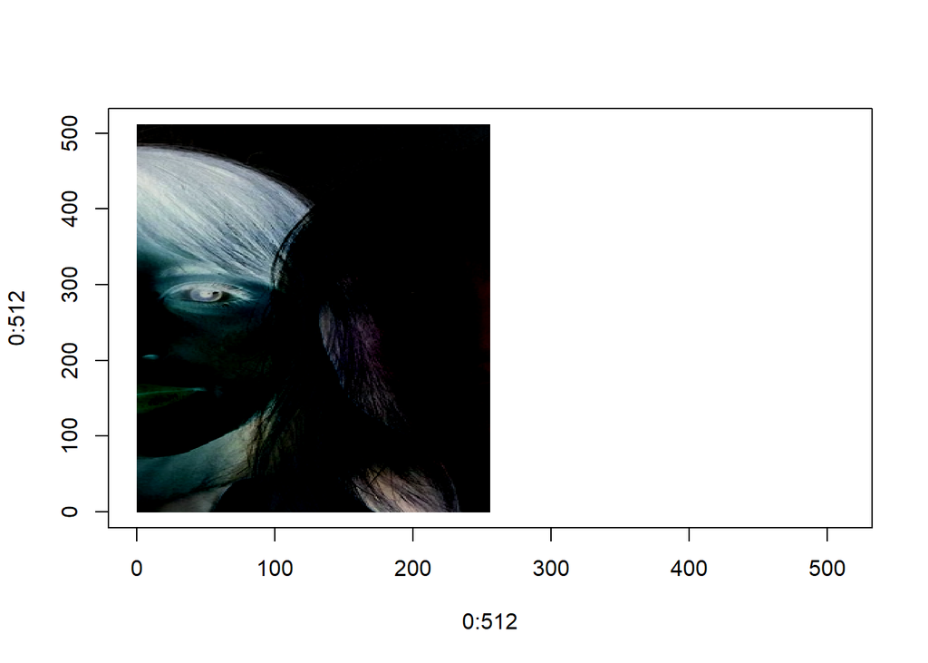

```r
newPhoto <- redSubtract + greenSubtract + blueSubtract

plot(0:512, 0:512, type="n")
rasterImage(newPhoto,
            0, 0, 256, 512,
            interpolate=FALSE)
```

Below, I displayed each subtracted channel as a seperate image.

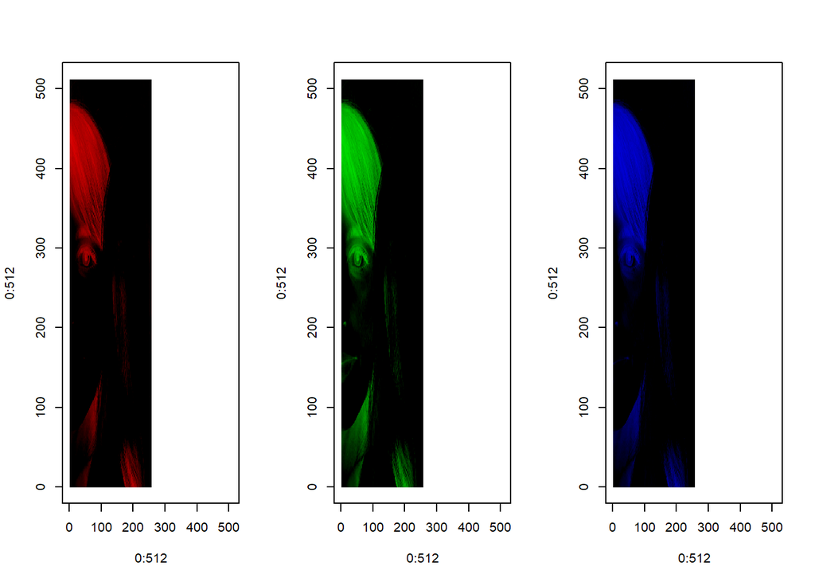

```r
par(mfrow=c(1,3))
plot(0:512, 0:512, type="n")
rasterImage(redSubtract,
            0, 0, 256, 512,
            interpolate=FALSE)

plot(0:512, 0:512, type="n")
rasterImage(greenSubtract,
            0, 0, 256, 512,
            interpolate=FALSE)

plot(0:512, 0:512, type="n")
rasterImage(blueSubtract,
            0, 0, 256, 512,
            interpolate=FALSE)
```

**E)** To add noise, first I have generated random noise ~ U(0,0.1) for each channel of the original image seperately.

```r
redNoise <- matrix(runif(512*512,0,0.1), 512, 512)
greenNoise <- matrix(runif(512*512,0,0.1), 512, 512)
blueNoise <- matrix(runif(512*512,0,0.1), 512, 512)
```

Then, I have added added noises to related channels.

```r
noisedRed <- redChannel[1:512, 1:512, 1] + redNoise
noisedGreen <- greenChannel[1:512, 1:512, 2] + greenNoise
noisedBlue <- blueChannel[1:512, 1:512, 3] + blueNoise
```

However, we have values greater than 1 since we have summed random noise values and channel values for each colour, we need to scale the each element between 0 and 1. Then, we need normalization.

```r
noisedRed = (noisedRed - min(noisedRed)) / (max(noisedRed)-min(noisedRed))
noisedGreen = (noisedGreen- min(noisedGreen)) / (max(noisedGreen)-min(noisedGreen))
noisedBlue = (noisedBlue - min(noisedBlue)) / (max(noisedBlue)-min(noisedBlue))
```

Since I need to combine these three matrices to display the new noised image, I have changed the each channel of the original photo into the noised ones.

```r
noisedPhoto = photo
noisedPhoto[,,1] = noisedRed
noisedPhoto[,,2] = noisedGreen
noisedPhoto[,,3] = noisedBlue
```

Then, new noisy image is displayed below.

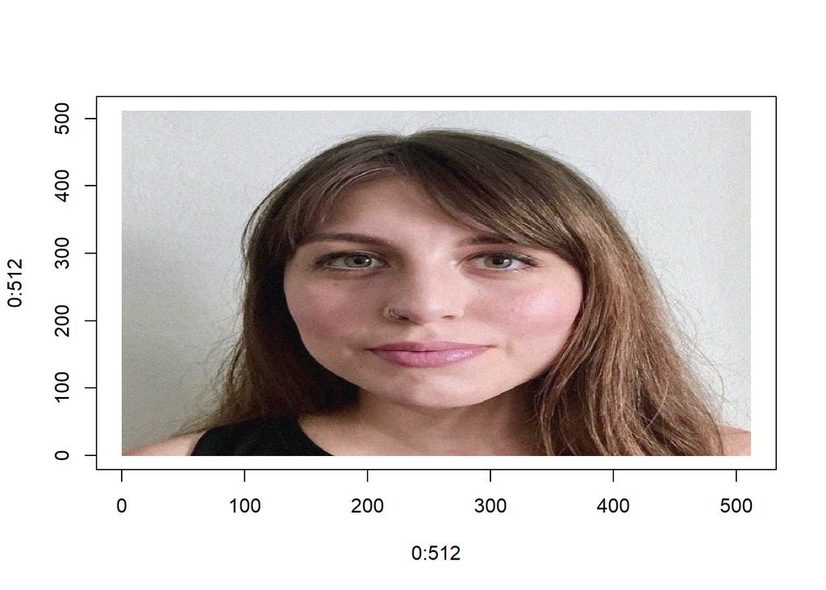

```r
plot(0:512, 0:512, type="n")
rasterImage(noisedPhoto,
            0, 0, 512, 512,
            interpolate=FALSE)
```

Images of each noisy channels are also shown below.

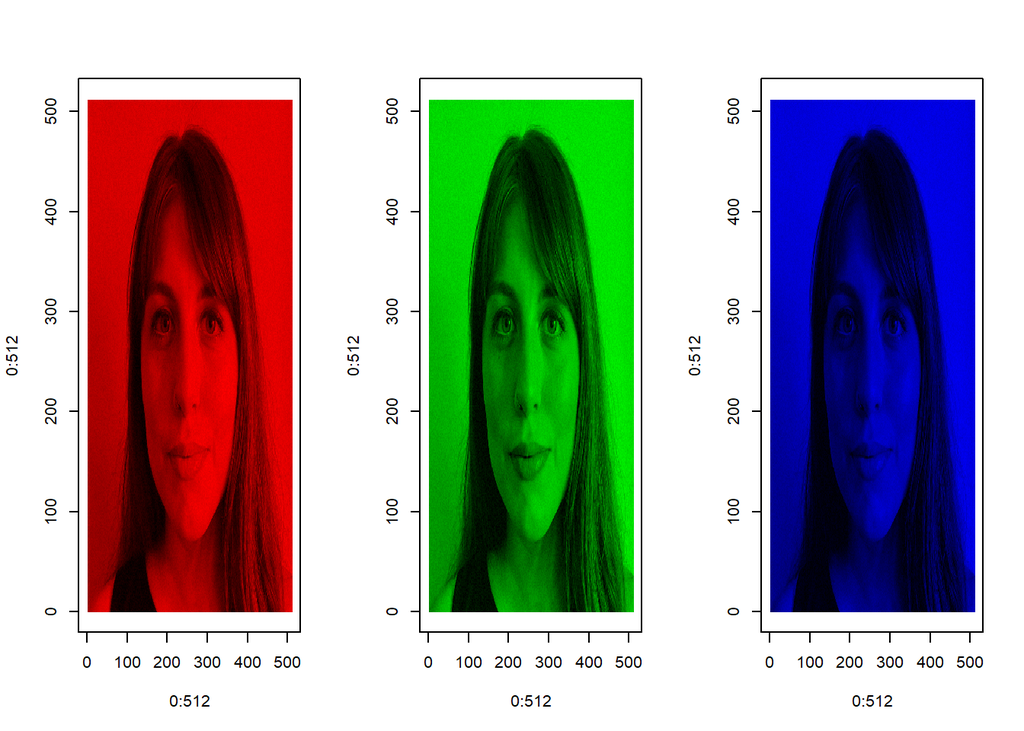

```r
par(mfrow=c(1,3))
redNoised <- noisedPhoto
redNoised[,,2:3]=0
plot(0:512, 0:512, type="n")
rasterImage(redNoised,
            0, 0, 512, 512,
            interpolate=FALSE)

greenNoised <- noisedPhoto
greenNoised[,,c(1,3)]=0
plot(0:512, 0:512, type="n")
rasterImage(greenNoised,
            0, 0, 512, 512,
            interpolate=FALSE)

blueNoised <- noisedPhoto
blueNoised[,,1:2]=0
plot(0:512, 0:512, type="n")
rasterImage(blueNoised,
            0, 0, 512, 512,
            interpolate=FALSE)
```